# weather

### 2.2.6 분류분석의 시각화

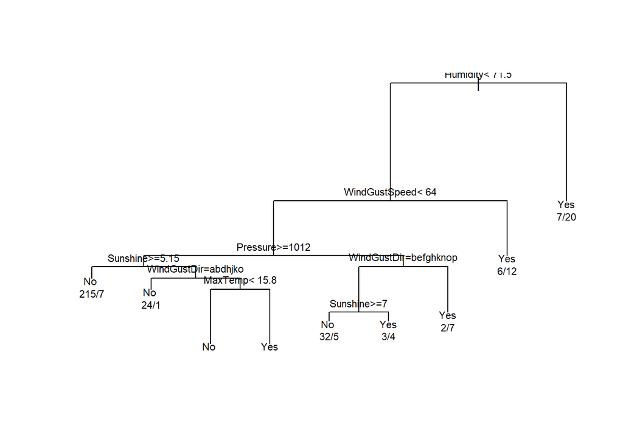

```r
# X11() # 차트를 띄울 별도의 창 생성
plot(weather.df) # 트리 프레임 보임
text(weather.df, use.n = T, cex=0.7) # 텍스트 추가
```

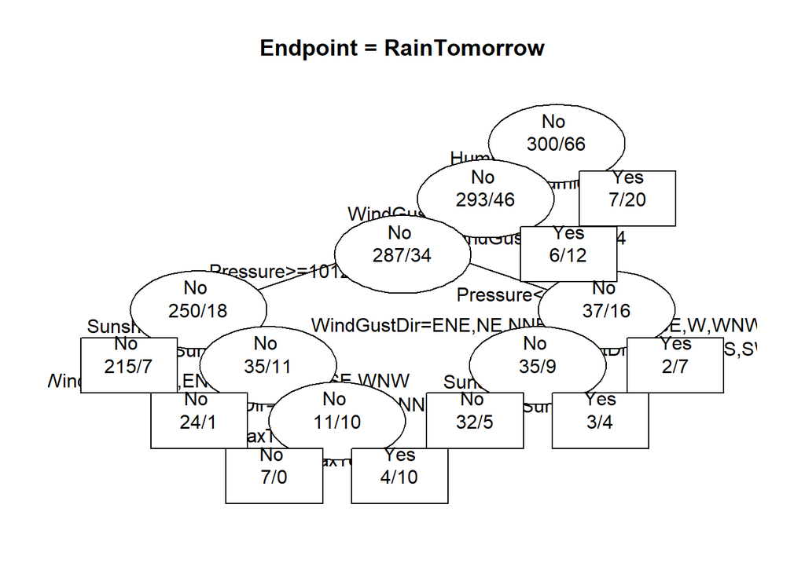

```r
post(weather.df, file="") # 타원제공 - rpart 패키지 제공
```

- Humidity >= 71.5일 때 RainTomorrow는 Yes:20, No:7
- Humidity < 71.5 이고 WindGustSpeed >= 64이면 RainTomorrow는 Yes:12, No:6
- 분기 조건의 참일 때 왼쪽, 거짓일 때 오른쪽으로 분류
- rpart() 함수의 cp 속성값을 높이면 가지수가 적어지고, 낮추면 가지 수가 많아진다.
- cp의 기본 값은 0.01

### 2.2.7 예측치 생성과 코딩 변경

#### 2.2.7.1 예측치 생성

```r
weather_pred <- predict(weather.df, weather)
head(weather_pred)
```

```
##          No        Yes
## 1 0.9684685 0.03153153
## 2 0.8648649 0.13513514
## 3 0.3333333 0.66666667
## 4 0.8648649 0.13513514
## 5 0.9684685 0.03153153
## 6 0.9684685 0.03153153
```

```r
weather_pred2 <- ifelse(weather_pred[,2] >= 0.7, 'Yes', 'No' )
```

- rpart의 분류모델의 예측치는 비 유무를 0 ~ 1 사이의 확률값으로 예측한다.
- 따라서 0.7 이상이면 비가 오는 경우로, 0.7 미만이면 비가 오지 않는 경우로 범주화하여 코딩 변경해야 혼돈 매트릭스를 이용하여 분류정확도를 구할 수 있다.

### 2.2.8 모델 평가

```r
table(weather_pred2, weather$RainTomorrow)
```

```
##
## weather_pred2  No Yes
##           No  287  29
##           Yes  13  37
```

```r
(287 + 37) / nrow(weather)
```

```
## [1] 0.8852459
```

- y 변수의 범주로 코딩 변경한 변수를 대상으로 원형 데이터의 y변수와 혼돈 매트릭스를 작성하여 분류정확도를 계산